# Airplane Passenger Time Series

Jie (Laurie) Zhang

April 12, 2015

Studying to analyze time series and build ARIMA predictive model. The great similarity between the time series analysis with the random stochastic process refreshed my memory from the previous class in EE 514

### The framework shows my approach for this time series analysis:

- Visualize the time series
- Stationarize the series
- Plot ACF/PACF charts and find optimal parameters
- Build the ARIMA model
- Make Predictions

### Step 1: Visualize the time series

It is very essential to analyze the trends prior to building any kind of time series model. The details we are interested in pertains to any kind of trend, seasonality or random behaviour in the series.

The cycle of this time series is 12 months in a year. Let’s gather some general statistic about the data:

```
##    Min. 1st Qu.  Median    Mean 3rd Qu.    Max.
##   104.0   180.0   265.5   280.3   360.5   622.0
```

Examining the distribution spectrum of the number of passengers. The fitted line suggests the trend of the number of passengers from 1949 to 1961:

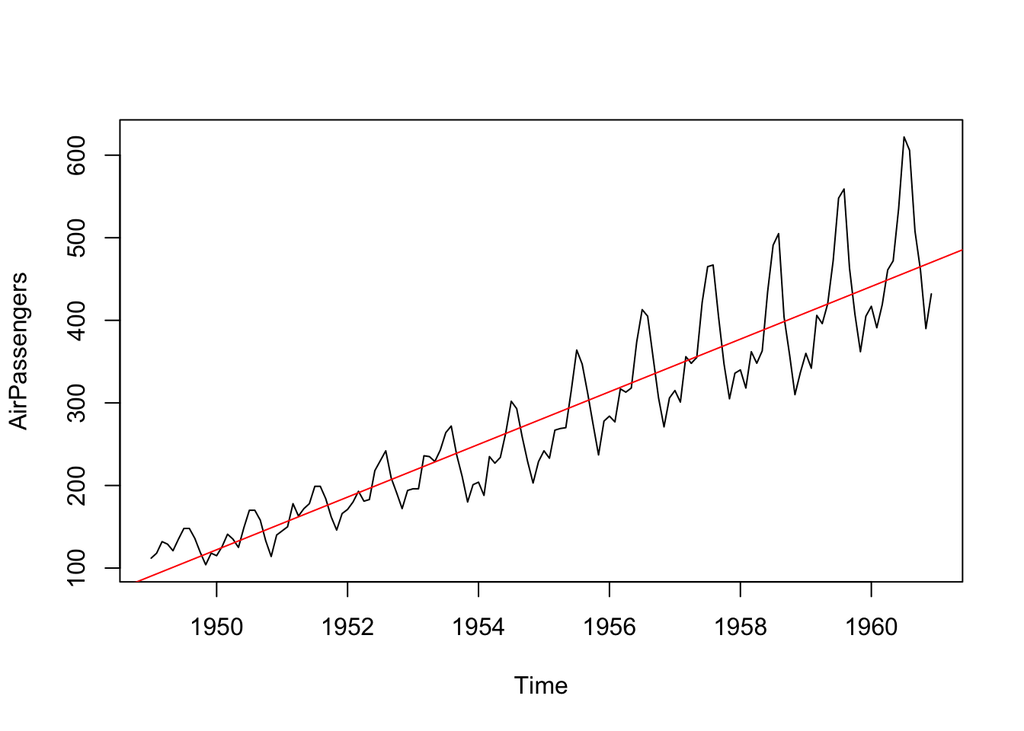

Aggregate the number of passengers by year and plot the year trend

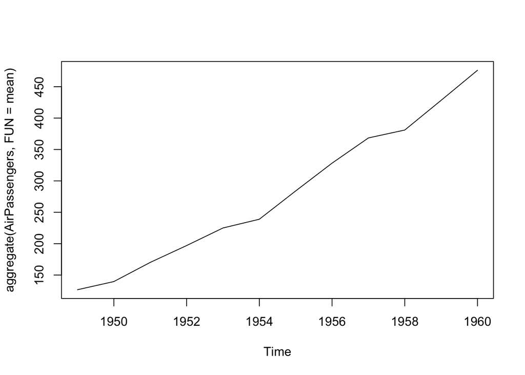

Box plot across months will give us a sense on seasonal effect

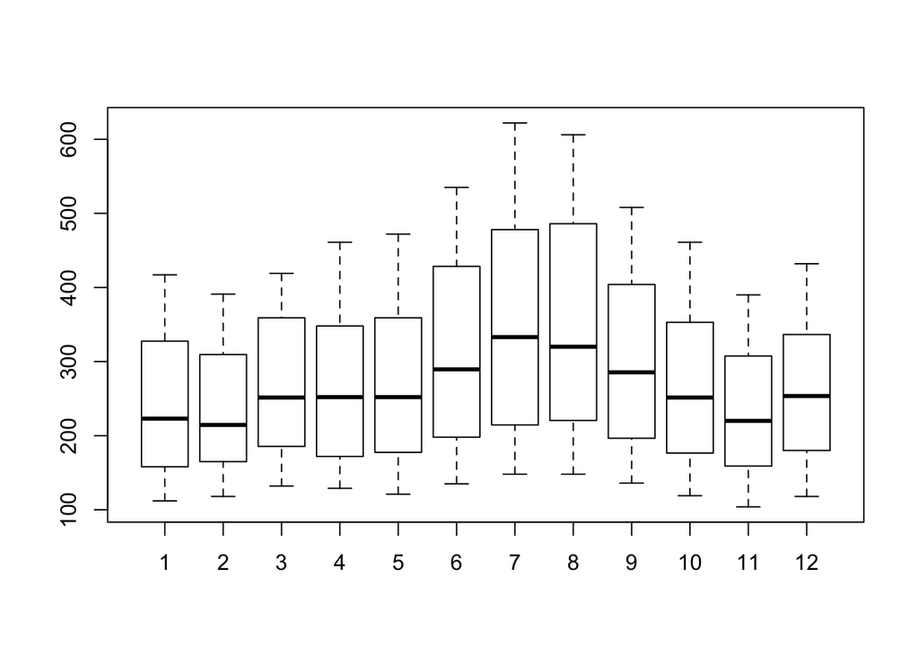

### So here we can get a few inferences:

1. The year on year trend clearly shows that the #passengers have been increasing without fail.
2. The variance and the mean value in July and August is much higher than rest of the months.
3. Even though the mean value of each month is quite different their variance is small. Hence, we have strong seasonal effect with a cycle of 12 months or less.
4. The variance in the data keeps on increasing with time.

### Step 2: Stationarize the series

Once we know the patterns, trends, cycles and seasonality , we can check if the series is stationary or not. Dickey – Fuller is one of the popular test to check the same. There are three commonly used technique to make a time series stationary: 1. **Detrending** : Here, we simply remove the trend component from the time series. For instance, the equation of my time series is: $x(t) = (mean + trend * t) + error$ We’ll simply remove the part in the parentheses and build model for the rest.

2. **Differencing** : This is the commonly used technique to remove non-stationarity. Here we try to model the differences of the terms and not the actual term. For instance, $x(t) – x(t-1) = ARMA (p, q)$ This differencing is called as the Integration part in AR(I)MA. Now, we have three parameters: **p:AR, d:I, q:MA**
3. **Seasonality** : Seasonality can easily be incorporated in the ARIMA model directly. More on this has been discussed in the applications part below.

We know that we need to address two issues before we test stationary series. One, we need to remove unequal variances. We do this using log of the series. Two, we need to address the trend component. We do this by taking difference of the series. Now, let’s test the resultant series.

```
##
##  Augmented Dickey-Fuller Test
##
## data:  diff(log(AirPassengers))
## Dickey-Fuller = -9.6003, Lag order = 0, p-value = 0.01
## alternative hypothesis: stationary
```

We see that the series is stationary enough to do any kind of time series modelling.

### Step 3: Find optimal parameters

The parameters p,d,q can be found using ACF and PACF plots. An addition to this approach is can be, if both ACF and PACF decreases gradually, it indicates that we need to make the time series stationary and introduce a value to “d”.

We already know that the ‘d’ component is 1 as we need 1 difference to make the series stationary. We do this using the Correlation plots. Following are the ACF plots for the log of the series :

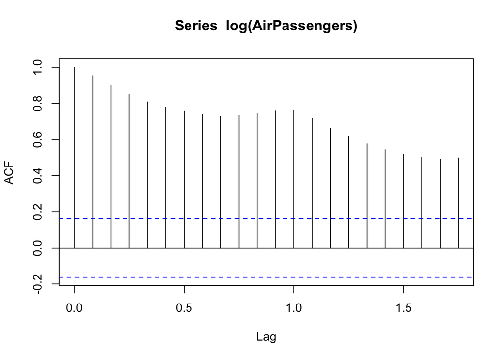

Clearly, the decay of ACF chart is very slow, which means that the population is not stationary. We have already discussed above that we now intend to regress on the difference of logs rather than log directly. Let’s see how ACF and PACF curve come out after regressing on the difference.

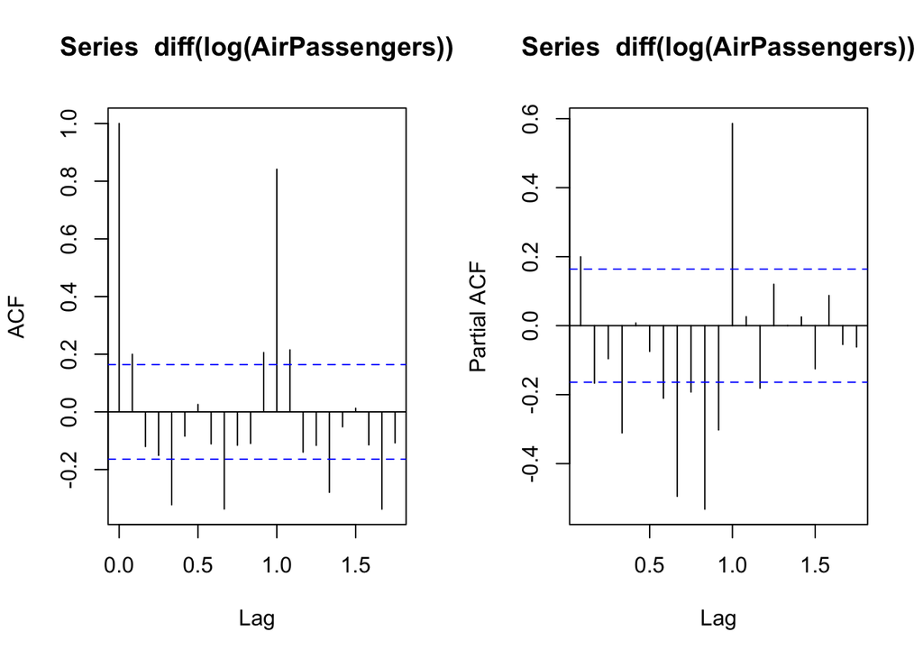

Clearly, ACF plot cuts off after the first lag. Hence, we understood that value of p should be 0 as the ACF is the curve getting a cut off. While value of q should be 1 or 2.

### Step 4: Build ARIMA model

The value found in the previous section might be an approximate estimate and we need to explore more (p,d,q) combinations. The one with the lowest BIC and AIC should be our choice. We can also try some models with a seasonal component, since we noticed seasonality in ACF/PACF plots.

```
##
## Call:
## arima(x = log(AirPassengers), order = c(0, 1, 1), seasonal = list(order = c(0,
##     1, 1), period = 12))
##
## Coefficients:
##           ma1     sma1
##       -0.4018  -0.5569
## s.e.   0.0896   0.0731
##
## sigma^2 estimated as 0.001348:  log likelihood = 244.7,  aic = -483.4
```

```
##
## Call:
## arima(x = log(AirPassengers), order = c(0, 1, 2), seasonal = list(order = c(0,
##     1, 2), period = 12))
##
## Coefficients:
##          ma1      ma2     sma1   sma2
##       -0.408  -0.0373  -0.5994  0.067
## s.e.   0.087   0.0849   0.0949  0.091
##
## sigma^2 estimated as 0.001338:  log likelihood = 245.08,  aic = -480.16
```

After a few iterations, we found that (0,1,1) as (p,d,q) comes out to be the combination with least AIC.

### Step 5: Make Predictions

We are now ready to make predictions on the future 10 years. We can also visualize the trends to cross validate if the model works fine.

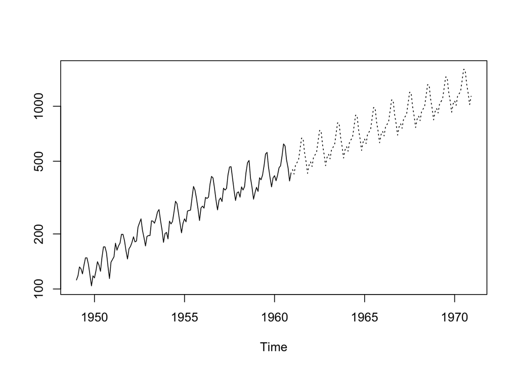

The predictions appear to be seamless when we look along with the training data. We are also able to bring out increasing variance, trend, seasonality in the prediction.